# Weather Type Classification: Custom Logistic Regression vs. Scikit-learn

Created by: Florian Hurlbert and Kimberly McNeil (Fall 2024)

Our Data Set: Weather Type Classification

Dateset Link: https://www.kaggle.com/datasets/nikhil7280/weather-type-classification

## 1. Preparation and Overview

### Classification Task

This dataset is meant for machine learners. It explicitly states that the data is made up for learning, so this model wouldn't be useful in deployment. That being said the task of identifying weather conditions is old as time and something I imagine ML models are already being trained to help with (if not already deployed in some places).

The target variable we are predicting in this dataset is the "Weather Type", Rainy, Sunny, Cloudy, or Snowy. This task is one done by weather apps already, giving people a rough estimate of what the weather is like based on many factors so they can prepare to go about their day. I believe a model like this could be deployed and fed data periodically throughout the day, at which point it can output what the weather is like in places for users.

This task is not one which requires an extraordinarily high amount of accuracy, as getting the weather wrong is not the biggest of deals. At worst a user of the model may be dressed innapropriately for the weather. In most cases this may lead to mild discomfort, or a loss of time due to changing. But a classifier of this type cannot be too innaccurate or it will be discarded. People remember when their weather app gave them the wrong information. If it is wrong to often, people will abandon it in favor of something else. It must be rememebered that "Window Weather" is an option for most people, so a classifier needs to have decently high accuracy to incentivize people over that.

### Define and Prepare Class Variables

```python
import pandas as pd
import numpy as np
import matplotlib.pyplot as plt
import seaborn as sns

from sklearn import metrics
from sklearn.preprocessing import LabelEncoder
from sklearn.preprocessing import StandardScaler
from sklearn.linear_model import LogisticRegression

le = LabelEncoder()
```

```python
import warnings
warnings.filterwarnings('ignore')
```

```python
from google.colab import drive
drive.mount('/content/drive')
```

```python
df = pd.read_csv('/content/drive/MyDrive/Fall 2024/Intro To Machine Learning/Project 2/weather_classification_data.csv')
```

```python
df.head()
```

|  | Temperature | Humidity | Wind Speed | Precipitation (%) | Cloud Cover | Atmospheric Pressure | UV Index | Season | Visibility (km) | Location | Weather Type |
| --- | --- | --- | --- | --- | --- | --- | --- | --- | --- | --- | --- |
| 0 | 14.0 | 73 | 9.5 | 82.0 | partly cloudy | 1010.82 | 2 | Winter | 3.5 | inland | Rainy |
| 1 | 39.0 | 96 | 8.5 | 71.0 | partly cloudy | 1011.43 | 7 | Spring | 10.0 | inland | Cloudy |
| 2 | 30.0 | 64 | 7.0 | 16.0 | clear | 1018.72 | 5 | Spring | 5.5 | mountain | Sunny |
| 3 | 38.0 | 83 | 1.5 | 82.0 | clear | 1026.25 | 7 | Spring | 1.0 | coastal | Sunny |
| 4 | 27.0 | 74 | 17.0 | 66.0 | overcast | 990.67 | 1 | Winter | 2.5 | mountain | Rainy |

A few of the inputs are strings, so we have to map them.

```python
# Getting the original values and counts of each
df['Cloud Cover'].value_counts()
```

| Cloud Cover | count |
| --- | --- |
| overcast | 6090 |
| partly cloudy | 4560 |
| clear | 2139 |
| cloudy | 411 |

**dtype:** int64

```python
# Turn the Strings into Integer Values
# Transforms the values into intergers
df['Cloud Cover'] = le.fit_transform(df[['Cloud Cover']])
# Shows the count to verify each has the same number as prior
df['Cloud Cover'].value_counts()
```

| Cloud Cover | count |
| --- | --- |
| 2 | 6090 |
| 3 | 4560 |
| 0 | 2139 |
| 1 | 411 |

**dtype:** int64

```python
# Getting the original values and counts of each
df['Season'].value_counts()
```

| Season | count |
| --- | --- |
| Winter | 5610 |
| Spring | 2598 |
| Autumn | 2500 |
| Summer | 2492 |

**dtype:** int64

```python
# Transforms the values into intergers
df['Season'] = le.fit_transform(df[['Season']])
# Shows the count to verify each has the same number as prior
df['Season'].value_counts()
```

| Season | count |
| --- | --- |
| 3 | 5610 |
| 1 | 2598 |
| 0 | 2500 |
| 2 | 2492 |

**dtype:** int64

```python
# Getting the original values and counts of each
df['Location'].value_counts()
```

| Location | count |
| --- | --- |
| inland | 4816 |
| mountain | 4813 |
| coastal | 3571 |

**dtype:** int64

```python
# Transforms the values into intergers
df['Location'] = le.fit_transform(df[['Location']])
# Shows the count to verify each has the same number as prior
df['Location'].value_counts()
```

| Location | count |
| --- | --- |
| 1 | 4816 |
| 2 | 4813 |
| 0 | 3571 |

**dtype:** int64

Now...

- Cloud Cover
  - clear = 0
  - cloudy = 1
  - overcast = 2
  - partly cloudy = 3
- Season
  - Autumn = 0
  - Spring = 1
  - Summer = 2
  - Winter = 3
- Location
  - coastal = 0
  - inland = 1
  - mountain = 2

```python
# Put the inputs together
X = df[['Temperature', 'Humidity', 'Wind Speed', 'Precipitation (%)', 'Cloud Cover', 'Atmospheric Pressure', 'UV Index', 'Season', 'Visibility (km)', 'Location']]
X.head()
```

|  | Temperature | Humidity | Wind Speed | Precipitation (%) | Cloud Cover | Atmospheric Pressure | UV Index | Season | Visibility (km) | Location |
| --- | --- | --- | --- | --- | --- | --- | --- | --- | --- | --- |
| 0 | 14.0 | 73 | 9.5 | 82.0 | 3 | 1010.82 | 2 | 3 | 3.5 | 1 |
| 1 | 39.0 | 96 | 8.5 | 71.0 | 3 | 1011.43 | 7 | 1 | 10.0 | 1 |
| 2 | 30.0 | 64 | 7.0 | 16.0 | 0 | 1018.72 | 5 | 1 | 5.5 | 2 |
| 3 | 38.0 | 83 | 1.5 | 82.0 | 0 | 1026.25 | 7 | 1 | 1.0 | 0 |
| 4 | 27.0 | 74 | 17.0 | 66.0 | 2 | 990.67 | 1 | 3 | 2.5 | 2 |
| ... | ... | ... | ... | ... | ... | ... | ... | ... | ... | ... |
| 13195 | 10.0 | 74 | 14.5 | 71.0 | 2 | 1003.15 | 1 | 2 | 1.0 | 2 |
| 13196 | -1.0 | 76 | 3.5 | 23.0 | 1 | 1067.23 | 1 | 3 | 6.0 | 0 |
| 13197 | 30.0 | 77 | 5.5 | 28.0 | 2 | 1012.69 | 3 | 0 | 9.0 | 0 |
| 13198 | 3.0 | 76 | 10.0 | 94.0 | 2 | 984.27 | 0 | 3 | 2.0 | 1 |
| 13199 | -5.0 | 38 | 0.0 | 92.0 | 2 | 1015.37 | 5 | 0 | 10.0 | 2 |

13200 rows × 10 columns

Time for the output feature, which is also a string we need to map!

```python
# Output Feature
# Getting the original values and counts of each
df['Weather Type'].value_counts()
```

| Weather Type | count |
| --- | --- |
| Rainy | 3300 |
| Cloudy | 3300 |
| Sunny | 3300 |
| Snowy | 3300 |

**dtype:** int64

```python
# Transforms the values into intergers
df['Weather Type'] = le.fit_transform(df[['Weather Type']])
# Shows the count to verify each has the same number as prior
df['Weather Type'].value_counts()
```

| Weather Type | count |
| --- | --- |
| 1 | 3300 |
| 0 | 3300 |
| 3 | 3300 |
| 2 | 3300 |

**dtype:** int64

Now, for Weather Type...

- Cloudy = 0
- Rainy = 1
- Snowy = 2
- Sunny = 3

```python
# Verifying the y dataframe
y = df[['Weather Type']]
y
```

|  | Weather Type |
| --- | --- |
| 0 | 1 |
| 1 | 0 |
| 2 | 3 |
| 3 | 3 |
| 4 | 1 |
| ... | ... |
| 13195 | 1 |
| 13196 | 2 |
| 13197 | 0 |
| 13198 | 2 |
| 13199 | 1 |

13200 rows × 1 columns

```python
# Scaling the Input Features
scaler = StandardScaler()
X = scaler.fit_transform(X)
```

```python
# Means and standard deviations of the scaled input features
# This is to show that after using Standard Scaling, the mean is essentially 0,
# and the Standard Deviation (std) is essentially 1.
feature_indices = {'Temperature': 0, 'Humidity': 1, 'Wind Speed': 2, 'Precipitation (%)':3, 'Cloud Cover':4, 'Atmospheric Pressure':5, 'UV Index':6, 'Season':7, 'Visibility (km)':8, 'Location':9}

print(f"Temperature Mean: {X[:, feature_indices['Temperature']].mean()}")
print(f"Humidity Mean: {X[:, feature_indices['Humidity']].mean()}")
print(f"Wind Speed Mean: {X[:, feature_indices['Wind Speed']].mean()}")
print(f"Precipitation (%) Mean: {X[:, feature_indices['Precipitation (%)']].mean()}")
print(f"Cloud Cover Mean: {X[:, feature_indices['Cloud Cover']].mean()}")
print(f"Atmospheric Pressure Mean: {X[:, feature_indices['Atmospheric Pressure']].mean()}")
print(f"UV Index Mean: {X[:, feature_indices['UV Index']].mean()}")
print(f"Season Mean: {X[:, feature_indices['Season']].mean()}")
print(f"Visibility (km) Mean: {X[:, feature_indices['Visibility (km)']].mean()}")
print(f"Location Mean: {X[:, feature_indices['Location']].mean()}")
print()

print(f"Temperature std: {X[:, feature_indices['Temperature']].std()}")
print(f"Humidity std: {X[:, feature_indices['Humidity']].std()}")
print(f"Wind Speed std: {X[:, feature_indices['Wind Speed']].std()}")
print(f"Precipitation (%) std: {X[:, feature_indices['Precipitation (%)']].std()}")
print(f"Cloud Cover std: {X[:, feature_indices['Cloud Cover']].std()}")
print(f"Atmospheric Pressure std: {X[:, feature_indices['Atmospheric Pressure']].std()}")
print(f"UV Index std: {X[:, feature_indices['UV Index']].std()}")
print(f"Season std: {X[:, feature_indices['Season']].std()}")
print(f"Visibility (km) std: {X[:, feature_indices['Visibility (km)']].std()}")
print(f"Location std: {X[:, feature_indices['Location']].std()}")
```

```
Temperature Mean: -6.136505445200865e-17
Humidity Mean: 3.445055688533819e-16
Wind Speed Mean: 2.3684757858670008e-17
Precipitation (%) Mean: 1.0981115007201549e-16
Cloud Cover Mean: -2.799107746933728e-17
Atmospheric Pressure Mean: -5.307538920147415e-16
UV Index Mean: 4.8446095620006835e-18
Season Mean: -5.921189464667502e-18
Visibility (km) Mean: 3.768029659333865e-18
Location Mean: 7.53605931866773e-17

Temperature std: 0.9999999999999999
Humidity std: 0.9999999999999999
Wind Speed std: 1.0
Precipitation (%) std: 0.9999999999999999
Cloud Cover std: 1.0
Atmospheric Pressure std: 1.0
UV Index std: 0.9999999999999999
Season std: 0.9999999999999999
Visibility (km) std: 1.0
Location std: 0.9999999999999999
```

```python
# what does our dataset look like now?
df.head()
```

|  | Temperature | Humidity | Wind Speed | Precipitation (%) | Cloud Cover | Atmospheric Pressure | UV Index | Season | Visibility (km) | Location | Weather Type |
| --- | --- | --- | --- | --- | --- | --- | --- | --- | --- | --- | --- |
| 0 | 14.0 | 73 | 9.5 | 82.0 | 3 | 1010.82 | 2 | 3 | 3.5 | 1 | 1 |
| 1 | 39.0 | 96 | 8.5 | 71.0 | 3 | 1011.43 | 7 | 1 | 10.0 | 1 | 0 |
| 2 | 30.0 | 64 | 7.0 | 16.0 | 0 | 1018.72 | 5 | 1 | 5.5 | 2 | 3 |
| 3 | 38.0 | 83 | 1.5 | 82.0 | 0 | 1026.25 | 7 | 1 | 1.0 | 0 | 3 |
| 4 | 27.0 | 74 | 17.0 | 66.0 | 2 | 990.67 | 1 | 3 | 2.5 | 2 | 1 |
| ... | ... | ... | ... | ... | ... | ... | ... | ... | ... | ... | ... |
| 13195 | 10.0 | 74 | 14.5 | 71.0 | 2 | 1003.15 | 1 | 2 | 1.0 | 2 | 1 |
| 13196 | -1.0 | 76 | 3.5 | 23.0 | 1 | 1067.23 | 1 | 3 | 6.0 | 0 | 2 |
| 13197 | 30.0 | 77 | 5.5 | 28.0 | 2 | 1012.69 | 3 | 0 | 9.0 | 0 | 0 |
| 13198 | 3.0 | 76 | 10.0 | 94.0 | 2 | 984.27 | 0 | 3 | 2.0 | 1 | 2 |
| 13199 | -5.0 | 38 | 0.0 | 92.0 | 2 | 1015.37 | 5 | 0 | 10.0 | 2 | 1 |

13200 rows × 11 columns

There was no reason to remove any variables, as none of them are unnecessary. Additionally, we did not need to add any variables.

Now that all of the variables have been preprocessed, let’s break down each one.

- Temperature
  - The temperature in degrees Celsius, ranging from extreme cold to extreme heat.
  - Numeric (continuous)
  - float
  - Mean = 0
  - Standard deviation = 1
- Humidity
  - The humidity percentage, including values above 100% to introduce outliers.
  - Numeric (continuous)
  - float
  - Mean = 0
  - Standard deviation = 1
- Wind Speed
  - The wind speed in kilometers per hour, with a range including unrealistically high values.
  - Numeric (continuous)
  - float
  - Mean = 0
  - Standard deviation = 1
- Precipitation (%)
  - The precipitation percentage, including outlier values.
  - Numeric (continuous)
  - float
  - Mean = 0
  - Standard deviation = 1
- Cloud Cover
  - The cloud cover description.
  - Categorical (nominal)
  - Mapping
    - clear = 0
    - cloudy = 1
    - overcast = 2
    - partly cloudy = 3
  - Mean = 0
  - Standard deviation = 1
- Atmospheric Pressure
  - The atmospheric pressure in hPa, covering a wide range.
  - Numeric (continuous)
  - float
  - Mean = 0
  - Standard deviation = 1
- UV Index
  - The UV index, indicating the strength of ultraviolet radiation.
  - Numeric (discrete)
  - int
  - Mean = 0
  - Standard deviation = 1
- Season
  - The season during which the data was recorded.
  - Categorical (nominal)
  - Mapping
    - Autumn = 0
    - Spring = 1
    - Summer = 2
    - Winter = 3
  - Mean = 0
  - Standard deviation = 1
- Visibility (km)
  - The visibility in kilometers (km), including very low or very high values.
  - Numeric (continuous)
  - float
  - Mean = 0
  - Standard deviation = 1
- Location
  - The type of location where the data was recorded.
  - Categorical (nominal)
  - Mapping
    - coastal = 0
    - inland = 1
    - mountain = 2
  - Mean = 0
  - Standard deviation = 1
- Weather Type
  - The target variable for classification, indicating the weather type.
  - Categorical (nominal)
  - Mapping
    - Cloudy = 0
    - Rainy = 1
    - Snowy = 2
    - Sunny = 3

### 80/20 - Train/Test

```python
def train_test_split(X, y, test_size=0.2, random_state=None):
  if random_state:
    np.random.seed(random_state)

  # Create an array of indices and shuffle them
  indices = np.arange(X.shape[0])
  np.random.shuffle(indices)

  # Calculate the split index
  split_idx = int(X.shape[0] * (1 - test_size))

  # Split the indices into training and testing sets
  train_indices = indices[:split_idx]
  test_indices = indices[split_idx:]

  X_train, X_test = X[train_indices], X[test_indices]
  y_train, y_test = y.iloc[train_indices], y.iloc[test_indices]

  return X_train, X_test, y_train, y_test
```

```python
X_train, X_test, y_train, y_test = train_test_split(X, y)
```

In researching the amount of data needed for training models, I came across the "10 times Rule", defined as "having at least 10 examples for each feature or predictor variable in your model". This rule is not perfect especially considering the variety of models and predicting tasks out there, many of which require much more data or have many many features and therefore realistically can't have 10 times that amount of data. As This rule was developed in the time of primarily linear and logistic regression models, specifically the type of model we are working with, it would seem too be appropriate for evaluating the appropriateness of our data here.

We have 10 features, so 10x10 would be 1000 instances for a hopefully appropriate dataset. This dataset has 13,000+ instances, which is more than adequate given the 10 times rule.

Moreover, (considering the dataset is one made for learning), all the target classes have an equal number of instances of 3,300. This very equal distribution lessens the fear that removing to much of one group might have negative effects as it is very unlikely.

So there is no reason to lesson the amount of testing data to 10%. 80%-20% is completely fine to use in this case, although 70%-30% may also be appropriate considering the amount of data we have.

https://www.akkio.com/post/how-much-data-is-required-to-train-ml

https://postindustria.com/how-much-data-is-required-for-machine-learning/

## 2. Modeling

### Creating a Custom Logistic Regression Model

Here, we implemented a custom, one-versus-all logistic regression classifier using numpy. The implementation follows object-oriented conventions like scikit-learn. Addtitionally, the the logistic regression classifier has the following functionality added:

- Ability to choose optimization technique when class is instantiated: either steepest ascent (gradient descent), stochastic gradient ascent, and {Newton’s method/Quasi Newton methods}.

One-versus-all (OvA) is a strategy for multi-class classification where a binary classifier is trained for each class against all others. For n classes, n binary classifiers are trained. This approach transforms an n-class problem into n binary classification problems, where each problem distinguishes a given class from all other classes combined.*

```python
# Implementation tips:
# To implement these methods, you would need to define functions for the sigmoid,
# loss, gradient, and (for Newton’s method) Hessian calculations.
# Then, create update rules based on each method.

class LogisticRegressionOVA:

  def __init__(self, solver, learning_rate, num_iterations, penalty, C):
    self.solver = solver
    self.learning_rate = learning_rate
    self.num_iterations = num_iterations
    self.models = []  # List to hold models for each class
    self.penalty = penalty  # Regularization type: 'none', 'l1', 'l2', 'elasticnet'
    self.C = C  # Regularization strength (cost)


  def sigmoid(self, z):
    return 1 / (1 + np.exp(-z))

  def loss(self, y, y_pred):
    m = len(y)
    loss = -(1 / m) * np.sum(y * np.log(y_pred) + (1 - y) * np.log(1 - y_pred))
    return loss

  def compute_gradients(self, X, y, y_pred, theta):
    m = len(y)
    y = y.to_numpy().reshape(-1, 1)  # Ensure y is a column vector
    gradient = (1 / m) * np.dot(X.T, (y_pred - y))

    # Add regularization term to the gradient
    if self.penalty == 'l1':
        gradient[1:] += (self.C / m) * np.sign(theta[1:])
    elif self.penalty == 'l2':
        gradient[1:] += (self.C / m) * theta[1:]
    elif self.penalty == 'elasticnet':
        gradient[1:] += (self.C / m) * (theta[1:] + np.sign(theta[1:]))


    return gradient

  def fit(self, X, y):
    m, n_features = X.shape
    num_classes = len(np.unique(y))  # Number of unique classes

    # Add bias term to X
    X = np.c_[np.ones((m, 1)), X]  # Add column of ones to X for the bias term

    self.models = []  # initialize self.models as an empty list

    for i in range(num_classes):
      # Create binary labels for class i
      y_binary = (y == i).astype(int)

      # Initialize theta for the current class
      theta = np.zeros((n_features + 1, 1))  # +1 for bias term

      # Fit the model for the current class
      for _ in range(self.num_iterations):
        z = np.dot(X, theta)
        y_pred = self.sigmoid(z)
        loss = self.loss(y_binary, y_pred)
        gradient = self.compute_gradients(X, y_binary, y_pred, theta)

        # Gradient Descent
        if self.solver == 'steepest_ascent':
          theta = theta - self.learning_rate * gradient

        # Stochastic gradient ascent updates
        elif self.solver == 'stochastic':
          theta = self.stochastic_gradient_ascent(X, y_binary, theta)

        # Newton's method updates
        elif self.solver == 'newton':
          theta = self.newton_method(X, y_binary, theta)

        else:
          raise ValueError("Invalid solver specified")

      # Store the model (theta) for class i
      self.models.append(theta)


  def stochastic_gradient_ascent(self, X, y, theta):
    # Stochastic gradient descent update
    i = np.random.randint(len(y))
    X_i = X[i:i+1]  # Select the i-th sample (row)
    y_i = y[i:i+1]  # Select the corresponding label

    h = self.sigmoid(np.dot(X_i, theta))
    gradient = self.compute_gradients(X_i, y_i, h, theta)
    theta = theta - self.learning_rate * gradient
    return theta

  def newton_method(self, X, y, theta):
    # Newton's method update (simplified)
    h = self.sigmoid(np.dot(X, theta))
    hessian = np.dot(X.T, X * h * (1 - h)) / len(y)
    gradient = self.compute_gradients(X, y, h, theta)
    theta = theta - np.dot(np.linalg.pinv(hessian), gradient)
    return theta


  def predict(self, X):
    # Add bias term to X
    X = np.c_[np.ones((X.shape[0], 1)), X]

    # Compute the probabilities for each class
    num_samples = X.shape[0]  # Get the number of samples in X
    probs = np.zeros((num_samples, len(self.models)))  # Initialize probs with correct shape

    for i, model in enumerate(self.models):
      z = np.dot(X, model)  # Calculate z for all samples
      probs[:, i] = self.sigmoid(z).ravel()  # Store probabilities for class i

    # Predict the class with the highest probability
    predictions = np.argmax(probs, axis=1)  # Choose the class with the highest probability

    # Reshape to a column vector with the correct number of rows
    return predictions.reshape(-1, 1)
```

I do not believe our project introduces any "data snooping". This is a bit hard to describe as in my research, data snooping is a bit more of an unethical practice than a small mistake you make while putting a model together. In many of the cases I read, data snooping referred to dishonest practices of running tests/adjusting things until you got a good result, and not considering the possible insignifianct reasons (for example, data which shows a false coorelation) data might appear signficiant. In our case, we used all of the parameters, so there was no searching through the data to introduce bias. We randomized the data which got split into training and testing, so there was no bias there. We also aren't testing on the same data we trained on, so there's no problems there either. We also got decent results from our model, so there was no going back and messing around with things to try and make it artificially better.

```python
# Options for solver
# 1. "steepest_ascent" -- gradient descent,
# 2. "stochastic"  -- stochastic gradient ascent, and
# 3. "newton" -- Newton’s method

# Regularization Options for the gradient
# 1. "l1" -- Lasso regression
# 2. "l2" -- Ridge regression
# 3. "elasticnet"


unique_train, counts_train = np.unique(y_train, return_counts=True)
unique_test, counts_test = np.unique(y_test, return_counts=True)

print("Training set class distribution:", dict(zip(unique_train, counts_train)))
print("Test set class distribution:", dict(zip(unique_test, counts_test)))


# Initialize OVA
# note, if you are using stochastic, set the penalty to none or adjust the learning rate and/or C.
# If you notice overfitting, try lowering C (e.g., C = 0.1, 0.01) to increase regularization. If underfit, do the reverse
OVA = LogisticRegressionOVA(solver='newton', learning_rate=0.01, num_iterations=1000, penalty='elasticnet', C=1.0)

# Fit the model
OVA.fit(X_train, y_train)

# Predict'
OVA_ypred = OVA.predict(X_test)

# Check first 10 predictions
print("Predictions: ", OVA_ypred[:10])
print("True labels: ", y_test[:10])
```

```
Training set class distribution: {0: 2631, 1: 2641, 2: 2653, 3: 2635}
Test set class distribution: {0: 669, 1: 659, 2: 647, 3: 665}
```

```
Predictions:  [[2]
 [2]
 [2]
 [0]
 [1]
 [1]
 [0]
 [2]
 [1]
 [2]]
True labels:         Weather Type
3516              2
9887              2
6692              2
6721              3
9880              1
11908             1
10496             0
12605             2
7215              0
9024              2
```

### Our Custom Model's Results

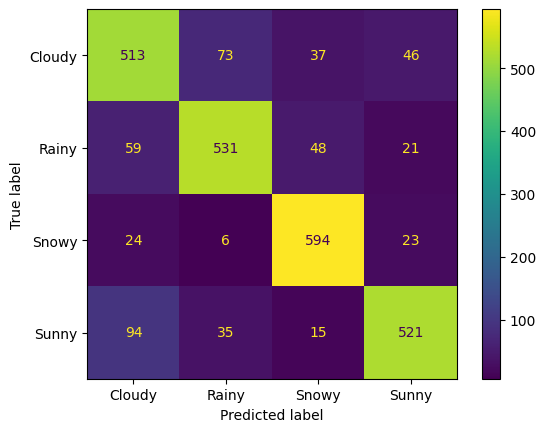

```
Weather Type
0               669
3               665
1               659
2               647
Name: count, dtype: int64
```

```python
# Confusion Matrix:
confusion_matrix = metrics.confusion_matrix(y_test, OVA_ypred)

cm_display = metrics.ConfusionMatrixDisplay(confusion_matrix = confusion_matrix, display_labels = ['Cloudy', 'Rainy', 'Snowy', 'Sunny'])

cm_display.plot()
plt.show()


# Count total observations (for checking that everything is there)
class_counts = y_test.value_counts()
print(class_counts)
```

```python
# We use an "weighted" average inorder to address
#   1. Class Imbalance (ex. sunny days might be much more frequent than snowy days in a particular region)
#   2. Error Importance (ex. misclassifying sunny when it's rainy (leads to thunder?) is more severe than
#      misclassifying rainy when it's actually sunny)
# If we didn't specify an average, it would assume that this is binary (only two classes)

# Precision
precision = metrics.precision_score(y_test, OVA_ypred, average='weighted')
print(f"Precision: {precision}")

# Recall (Sensitivity)
recall = metrics.recall_score(y_test, OVA_ypred, average='weighted')
print(f"Recall: {recall}")

# F1 Score
f1 = metrics.f1_score(y_test, OVA_ypred, average='weighted')
print(f"F1 Score: {f1}")

# Accuracy
accuracy = metrics.accuracy_score(y_test, OVA_ypred)
print(f"Accuracy: {accuracy}")
```

```
Precision: 0.8184585980018741
Recall: 0.8178030303030303
F1 Score: 0.8174255929253417
Accuracy: 0.8178030303030303
```

### Scikit-learn’s Logistic Regression Model's Results

```python
# Initialize and fit Scikit-learn’s Logistic Regression Model
logisticRegression = LogisticRegression()
logisticRegression.fit(X_train, y_train)

# Predict y
logypred = logisticRegression.predict(X_test)
```

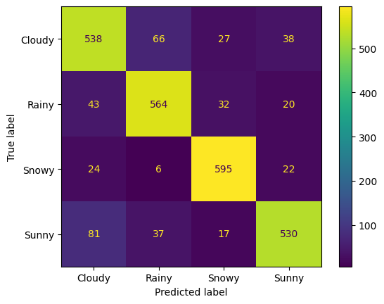

```python
# Confusion Matrix:
confusion_matrix = metrics.confusion_matrix(y_test, logypred)

cm_display = metrics.ConfusionMatrixDisplay(confusion_matrix = confusion_matrix, display_labels = ['Cloudy', 'Rainy', 'Snowy', 'Sunny'])

cm_display.plot()
plt.show()
```

```python
# We use an "weighted" average inorder to address
#   1. Class Imbalance (ex. sunny days might be much more frequent than snowy days in a particular region)
#   2. Error Importance (ex. misclassifying sunny when it's rainy (leads to thunder?) is more severe than
#      misclassifying rainy when it's actually sunny)
# If we didn't specify an average, it would assume that this is binary (only two classes)

# Precision
precision = metrics.precision_score(y_test, logypred, average='weighted')
print(f"Precision: {precision}")

# Recall (Sensitivity)
recall = metrics.recall_score(y_test, logypred, average='weighted')
print(f"Recall: {recall}")

# F1 Score
f1 = metrics.f1_score(y_test, logypred, average='weighted')
print(f"F1 Score: {f1}")

# Accuracy
accuracy = metrics.accuracy_score(y_test, logypred)
print(f"Accuracy: {accuracy}")
```

```
Precision: 0.8441061794384592
Recall: 0.843560606060606
F1 Score: 0.8433145468925709
Accuracy: 0.843560606060606
```

### Comparison

Now, let's compare the results from both of our models...

- Confusion Matrix (each of our four classes has all four of the following)
  - True Positives: The elements where both the predicted class and the observed class match.
  - False Positives: The elements where we are predicting one class, but it is observed to not be that class.
  - False Negatives: The elements where we are not predicting one class, but they are observed to be in that class anyway.
  - True Negatives: The elements that we are both not predicting and also do not belong to our predicted class

Our Model:

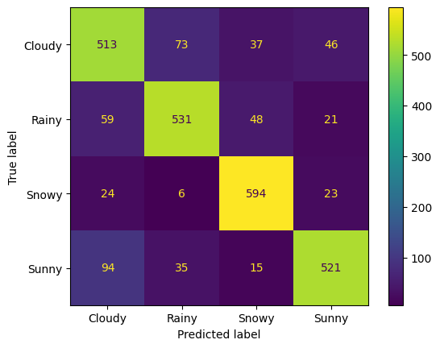

Scikit Learns Model:

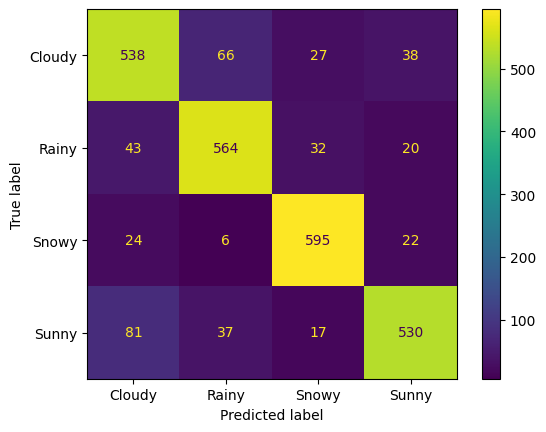

- Precision
  - Precision is the percentage of observed positives (for one class) out of all predicted positives (for that same class). We can have one precision with a weighted average, where each class's precision is weighted based on how many samples belong to that class in the dataset, giving more importance to the performance on larger classes and less importance to smaller classes

Scikit Learn's Overall Weighted Precision: 0.8441061794384592

I decided to also look at the precision rates by class to see if there was variation.

Cloudy:

- Our Model: 513/690 = 0.74348
- Scikit Learn: 538/686 = 0.78426

Rainy:

- Our Model: 531/645 = 0.82326
- Scikit Learn: 564/673 = 0.83804

Snowy:

- Our Model: 594/694 = 0.85591
- Scikit Learn: 595/671 = 0.88674

Sunny:

- Our Model: 521/611 = 0.8527
- Scikit Learn: 530/610 = 0.86885

While they are quite similar, we can see that across the board, Scikit Learn's model is a few percent more percise in every category, with the most improvement seen in the worst category for both models.

- Recall
  - Recall is the percentage of all of the correct predictions out of all actual positives. Like with precision, a weighted average will result in one recall (instead of one for each of the four classes we have)

Scikit Learn's Overall Weighted Recall: 0.843560606060606

To see a more clear difference breakdown I compared them by class again:

Cloudy:

- Our Model: 513/669 = 0.76682
- Scikit Learn: 538/669 = 0.80419

Rainy:

- Our Model: 531/659 = 0.80577
- Scikit Learn: 564/659 = 0.85584

Scikit Learns model continues to have the upper hand with a slightly larger gap in 2 of the classes for recall.

- F1 Score
  - The F1 Score is a metric which combines Precision and Recall (two metrics which are frequently inverse, optimizing to increase one often leads to decreses in the other). While some use cases call for optimizing for one over the other, the F1 Score is a helpful metric for evaluating overall performance in most models.

Scikit Learn's Overall Weighted F1-Score: 0.8433145468925709

The weighted averages again only show a small difference, but comparing the individual classes tells a different story.

Cloudy:

- Our Model: 0.75496
- Scikit Learn: 0.7941

Rainy:

- Our Model: 0.81442
- Scikit Learn: 0.84684

Snowy:

- Our Model: 0.8859
- Scikit Learn: 0.90288

Sunny:

- Our Model: 0.81662
- Scikit Learn: 0.83136

Of all the comparisons so far, this one shows the largest pull ahead, with all of Scikit Learns F1-scores being a couple of points ahead of our models.

- Accuracy
  - Accuracy is a blanket measure of what the model got right compared to all predictions made.

Scikit Learn's Overall Recall: 0.843560606060606

Unlike the other measures, the measurement of accuracy would be the same across all of the classes. So in this case, the overall accuracy is just close!

## 3. Deployment

After reviewing all the metrics side by side, while we created a model with decent metrics, I have to recommend Scikit Learns model over ours. In all metrics it preformed better than our own, so it is clearly the superior model, even if only by a little. And, when it comes to the weather, that little bit could mean a lot. As discussed at the beginning, while providing an incorrect assessment of the weather generally will not harm anyone, if it is wrong to often people will lose faith in the application. Therefore, the slightly higher performance, could mean quite a bit in deployment.

# Download in HTML

```python
### THIS IS TO TURN NOTEBOOK INTO HTML FORMAT AND DOWNLOAD:

from google.colab import files
uploaded_files = files.upload()

# Convert ipynb to html
import subprocess
notebook_filename = list(uploaded_files.keys())[0]
subprocess.run(["pip", "install", "nbconvert"])
subprocess.run(["jupyter", "nbconvert", notebook_filename, "--to", "html"])

# Download the html version
html_filename = notebook_filename[:-6] + ".html" # correct the slicing to avoid error
files.download(html_filename)
```

```
Saving Weather_Type_Classification_Custom_Logistic_Regression_vs_Scikit_learn (1).ipynb to Weather_Type_Classification_Custom_Logistic_Regression_vs_Scikit_learn (1).ipynb
```